# Credit Risk Modeling in R

DataCamp

Attila Toth

# Introduction and data preparation

This chapter begins with a general introduction to credit risk models, will explore a real-life data set, then preprocess the data set such that it’s in the appropriate format before applying the credit risk models.

## Sourcing data

In the beginning of the course we had been provided with data set, sourced from the following location: https://assets.datacamp.com/course/credit-risk-modeling-in-r/loan_data_ch1.rds We will be examining the dataset `loan_data` throughout the exercises in this course.

## Dataset Overview

```r
loan_data <- readRDS("loan_data_ch1.rds")
```

As always, it is recommended to take a quick first look at our data. With using `str()`, we can get an idea about the data structure. This case it tells us the following:

```r
str(loan_data)
```

```
## 'data.frame':    29092 obs. of  8 variables:
##  $ loan_status   : int  0 0 0 0 0 0 1 0 1 0 ...
##  $ loan_amnt     : int  5000 2400 10000 5000 3000 12000 9000 3000 10000 1000 ...
##  $ int_rate      : num  10.7 NA 13.5 NA NA ...
##  $ grade         : Factor w/ 7 levels "A","B","C","D",..: 2 3 3 1 5 2 3 2 2 4 ...
##  $ emp_length    : int  10 25 13 3 9 11 0 3 3 0 ...
##  $ home_ownership: Factor w/ 4 levels "MORTGAGE","OTHER",..: 4 4 4 4 4 3 4 4 4 4 ...
##  $ annual_inc    : num  24000 12252 49200 36000 48000 ...
##  $ age           : int  33 31 24 39 24 28 22 22 28 22 ...
```

Another view about the data if we use `head()` for displaying the first few rows.

```r
kable(head(loan_data))
```

| loan_status | loan_amnt | int_rate | grade | emp_length | home_ownership | annual_inc | age |
| --- | --- | --- | --- | --- | --- | --- | --- |
| 0 | 5000 | 10.65 | B | 10 | RENT | 24000 | 33 |
| 0 | 2400 | NA | C | 25 | RENT | 12252 | 31 |
| 0 | 10000 | 13.49 | C | 13 | RENT | 49200 | 24 |
| 0 | 5000 | NA | A | 3 | RENT | 36000 | 39 |
| 0 | 3000 | NA | E | 9 | RENT | 48000 | 24 |
| 0 | 12000 | 12.69 | B | 11 | OWN | 75000 | 28 |

We had been informed about the content of the columns in the course but without that the columns were very intuitively named.

| Variable Type | Variable | Description |
| --- | --- | --- |
| Response Variable | loan_status | 1 = loan defaulted, 0 = loan not defaulted |
| Explanatory Variables | loan_amt | Amount of the loan |
|  | int_rate | Interest rate applied on the loan |
|  | grade | Buro score of the customer; A-G highest-lowest class of creditworthiness. This reflects the credit history of the individual (behavioural variable) |
|  | emp_legth | Length of employment |
|  | home_ownership | Home ownership status |
|  | annual_inc | Annual income |
|  | age | Age of the customer |

After downloading and loading in `loan_data`, we are interested about the defaulted loans in the data set. We want to get an idea of the number, and percentage of defaults. Defaults are usually rare, so we always want to check what the proportion of defaults is in the examined dataset. The `gmodels::CrossTable()` function is very useful here.

```r
CrossTable(loan_data$loan_status)
```

```
##
##
##    Cell Contents
## |-------------------------|
## |                       N |
## |         N / Table Total |
## |-------------------------|
##
##
## Total Observations in Table:  29092
##
##
##           |         0 |         1 |
##           |-----------|-----------|
##           |     25865 |      3227 |
##           |     0.889 |     0.111 |
##           |-----------|-----------|
##
##
##
##
```

To learn more about variable structures and spot unexpected tendencies in the data, we should examine the relationship between `loan_status` and certain factor variables. For example, we would expect that the proportion of defaults in the group of customers with worse grades (worst credit rating score) is substantially higher than the proportion of defaults in the grade A group (best credit rating score).

```r
CrossTable(loan_data$grade, loan_data$loan_status,
           prop.r = T,
           prop.c = F,
           prop.t = F,
           prop.chisq = F
           )
```

```
##
##
##    Cell Contents
## |-------------------------|
## |                       N |
## |           N / Row Total |
## |-------------------------|
##
##
## Total Observations in Table:  29092
##
##
##                 | loan_data$loan_status
## loan_data$grade |         0 |         1 | Row Total |
## ----------------|-----------|-----------|-----------|
##               A |      9084 |       565 |      9649 |
##                 |     0.941 |     0.059 |     0.332 |
## ----------------|-----------|-----------|-----------|
##               B |      8344 |       985 |      9329 |
##                 |     0.894 |     0.106 |     0.321 |
## ----------------|-----------|-----------|-----------|
##               C |      4904 |       844 |      5748 |
##                 |     0.853 |     0.147 |     0.198 |
## ----------------|-----------|-----------|-----------|
##               D |      2651 |       580 |      3231 |
##                 |     0.820 |     0.180 |     0.111 |
## ----------------|-----------|-----------|-----------|
##               E |       692 |       176 |       868 |
##                 |     0.797 |     0.203 |     0.030 |
## ----------------|-----------|-----------|-----------|
##               F |       155 |        56 |       211 |
##                 |     0.735 |     0.265 |     0.007 |
## ----------------|-----------|-----------|-----------|
##               G |        35 |        21 |        56 |
##                 |     0.625 |     0.375 |     0.002 |
## ----------------|-----------|-----------|-----------|
##    Column Total |     25865 |      3227 |     29092 |
## ----------------|-----------|-----------|-----------|
##
##
```

The table above tells us, the proportion of defaults increases when the credit rating moves from A to G.

## Visuals

The best way to to explore continuous variables, to identify potential outliers or unexpected data structures is always some sort of quick visualization that can provide some early information before any further processing. So I just started off with simply plotting all variables in the dataset.

All of the plots had showed fairly expected results (so I excluded them from this documentation), except for the following two:

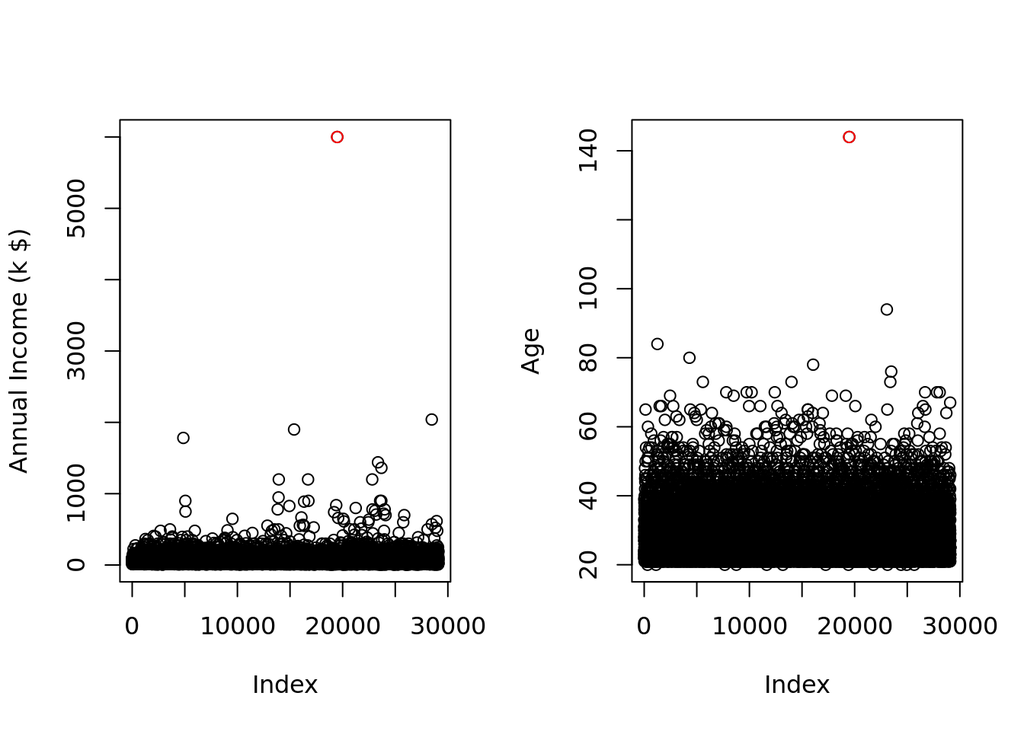

```r
par(mfrow=c(1,2))

plot(loan_data$annual_inc/1000, ylab = "Annual Income (k $)")
points(which(loan_data$annual_inc>5000000),
       loan_data$annual_inc[loan_data$annual_inc>5000000]/1000,
       col = "red")

plot(loan_data$age, ylab = "Age")
points(which(loan_data$age>100),
       loan_data$age[loan_data$age>100],
       col = "red")
```

## Outliers

Apparently, we encountered some outliers above around the age of **140** (!!) and annual income of **$6M**. Without having significant expertise in a particular business domain, a generally accepted way, a rule of thumb, to introduce outlier thresholds is to filter out data points that exceed the boundaries of interquartile range, the first quartile (Q1) and the third quartile (Q3), with more than 1.5 times the interquartile range (IQR) itself, i.e. values greater than Q3 + 1.5 x IQR or lower than Q1 - 1.5 x IQR.

```r
OL_age_threshold_low <- quantile(loan_data$age, 0.25)-1.5*IQR(loan_data$age)
OL_age_threshold_hi <- quantile(loan_data$age, 0.75)+1.5*IQR(loan_data$age)

OL_anninc_threshold_low <- quantile(loan_data$annual_inc, 0.25)-1.5*IQR(loan_data$annual_inc)
OL_anninc_threshold_hi <- quantile(loan_data$annual_inc, 0.75)+1.5*IQR(loan_data$annual_inc)
```

| Variable | Outlier Boundaries |  | Number of Observations Outer Boundaries |  |
| --- | --- | --- | --- | --- |
|  | Lower | Upper | Lower | Upper |
| age | 12.5 | 40.5 | 0 | 1325 |
| annual_inc | -20000 | 140000 | 0 | 1382 |

Luckily, our dataset was more or less tidy therefore no observation occured below the lower boundaries that would have actually made sense. Outer the upper boundaries we could see significant number of observations. The thresholds set for age and annual income variables, using the general outlier threshold rule, are sort of strict, given that we might assume by nature that customers above 40 years and $140k still belonged appropriately to our dataset. Therefore I decided to remove only those two extreme outliers (annual income above $6M and age above 130) from the dataset. (This happened to be one single observation.)

```r
OL_idx <- which(loan_data$annual_inc>5000000 | loan_data$age>130)
loan_data_nonOL <- loan_data[-OL_idx,]
```

My adjusted dataset showed the following distributions:

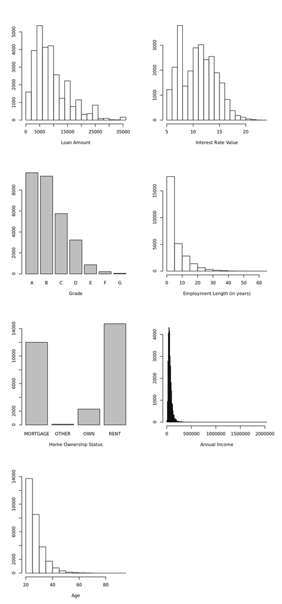

```r
par(mfrow=c(4,2))
hist(loan_data_nonOL$loan_amnt, main = "",
     xlab = "Loan Amount", ylab="")
hist(loan_data_nonOL$int_rate, main = "",
     xlab = "Interest Rate Value", ylab="")
plot(loan_data_nonOL$grade, main = "",
     xlab = "Grade")
hist(loan_data_nonOL$emp_length, main = "",
     xlab = "Employment Length (in years)", ylab="")
plot(loan_data_nonOL$home_ownership, main = "",
     xlab = "Home Ownership Status")
hist(loan_data_nonOL$annual_inc, main = "",
     breaks = sqrt(nrow(loan_data_nonOL)),
     xlab = "Annual Income", ylab="")
hist(loan_data_nonOL$age, main = "",
     xlab = "Age", ylab="")
```

## Missing Data

In case of missing data, the following strategies can be considered:

- **Deletion**: to delete observation or the entire variable. If there are only few observation having missing values, observations are to be deleted; in case of large number of missing value in a column, the deletion of the variable should be considered.
- **Replacement**: replacement with some central value, e.g. median imputation
- **Keep**: many models can not deal with missing values so eventually they just ignore (delete) those observations. To be on the safe side, we can perform the so-called coarse classification that transforms continuous variable into categorical providing us the opportunity to place missing values into an arbitrary bin.

| Strategy | Continuous Variable | Categorical Variable |
| --- | --- | --- |
| **Delete** | delete rows/columns | delete rows/columns |
| **Replace** | median imputation | using the most frequent category |
| **Keep** | keep as NA/coarse classification | create “missing” category |

Using `summary()` function on our dataset the number of missing values can be easily identified.

```r
summary(loan_data_nonOL)
```

```
##   loan_status       loan_amnt        int_rate     grade
##  Min.   :0.0000   Min.   :  500   Min.   : 5.42   A:9649
##  1st Qu.:0.0000   1st Qu.: 5000   1st Qu.: 7.90   B:9329
##  Median :0.0000   Median : 8000   Median :10.99   C:5747
##  Mean   :0.1109   Mean   : 9594   Mean   :11.00   D:3231
##  3rd Qu.:0.0000   3rd Qu.:12250   3rd Qu.:13.47   E: 868
##  Max.   :1.0000   Max.   :35000   Max.   :23.22   F: 211
##                                   NA's   :2776    G:  56
##    emp_length      home_ownership    annual_inc           age
##  Min.   : 0.000   MORTGAGE:12001   Min.   :   4000   Min.   :20.0
##  1st Qu.: 2.000   OTHER   :   97   1st Qu.:  40000   1st Qu.:23.0
##  Median : 4.000   OWN     : 2301   Median :  56400   Median :26.0
##  Mean   : 6.145   RENT    :14692   Mean   :  66965   Mean   :27.7
##  3rd Qu.: 8.000                    3rd Qu.:  80000   3rd Qu.:30.0
##  Max.   :62.000                    Max.   :2039784   Max.   :94.0
##  NA's   :809
```

First, the simpliest solution is the deletion of those records that carry NA values either in `emp_length` or in `int_rate` variables.

```r
NA_idx_del <- which(is.na(loan_data_nonOL$emp_length) | is.na(loan_data_nonOL$int_rate))
loan_data_nonOL_nonNA <- loan_data_nonOL[-NA_idx_del,]
```

In the second approach, I replaced NAs with the medians of the respective variables.

```r
median_int_rate <- median(loan_data_nonOL$int_rate, na.rm = T)
median_emp_length <- median(loan_data_nonOL$emp_length, na.rm = T)

loan_data_nonOL_med <- loan_data_nonOL

loan_data_nonOL_med[is.na(loan_data_nonOL_med$int_rate),"int_rate"] <- median_int_rate
loan_data_nonOL_med[is.na(loan_data_nonOL_med$emp_length),"emp_length"] <- median_emp_length
```

### Train - Test Split

In order to validate our model at a later point in time, we have to separate our dataset into training and testing sections before we start model build. We build our model, train our algorithm, on training set and verify it on the “unseen” testing set to get a realistic view about its performance.

We perform this separation usually with random sampling.

```r
set.seed(123)
train_idx <- sample(1:nrow(loan_data_nonOL_nonNA),2/3*nrow(loan_data_nonOL_nonNA))

loan_data_train <- loan_data_nonOL_nonNA[train_idx, ]
loan_data_test <- loan_data_nonOL_nonNA[-train_idx, ]
```